# Analysis on Japan&United State

# research

Wanxin Chen

2022-05-20

# Introduction

With the improvement of people’s living standards, more and more people begin to pay attention to diet. As we all know, a healthy diet can help us maintain a healthy body and figure, and effectively prevent dangerous diseases such as high blood pressure and high blood lipids. In our daily diet, our calorie intake mainly comes from three major nutrients, namely protein, fat and carbohydrates. Studies have shown that the proportion of the three major nutrients in the daily diet plays a very important role in human health. On the other hand, people in different regions have different eating habits due to differences in climate and terrain. The food culture of each country is very different, Americans love sweets and bread, Japanese love seafood and small dishes. In this report, I study the differences in diet between the United States and Japan and analyze the changes in the per capita calorie intake and the intake of the three major nutrients in the United States and Japan since 1960, starting from two aspects of eating habits and time trends A comparative analysis of the eating habits and health of the two countries.

```r
data <- read.csv("Data/daily-caloric-supply-derived-from-carbohydrates-protein-and-fat.csv")

mydata <- data %>% filter(Entity %in% c("United States","Japan"))
```

```r
pct_miss(mydata) #0 missingness in the UK and Iceland data
pct_miss_case(mydata)
pct_miss_var(mydata)
```

```r
mydata <- mydata %>%
  mutate(total_Cal = Calories.from.animal.protein..FAO..2017..
         +Calories.from.plant.protein..FAO..2017..
         +Calories.from.fat..FAO..2017..
         +Calories.from.carbohydrates..FAO..2017..,
         Protein_Cal=Calories.from.animal.protein..FAO..2017..
         +Calories.from.plant.protein..FAO..2017..,
         `Protein(%)`=percent((
           Calories.from.animal.protein..FAO..2017..
           +Calories.from.plant.protein..FAO..2017..)/total_Cal,
           accuracy = 4),
         `Fat(%)`=percent(
           Calories.from.fat..FAO..2017../total_Cal
           ,accuracy = 4),
         `Carbohydrates(%)`=percent(
           Calories.from.carbohydrates..FAO..2017../total_Cal,
           accuracy = 4))%>%
  rename(Fat_Cal=Calories.from.fat..FAO..2017..,
         Carbohydrates_Cal=Calories.from.carbohydrates..FAO..2017..,
         Animal_Protein_Cal=Calories.from.animal.protein..FAO..2017..,
         Plant_Protein_Cal=Calories.from.plant.protein..FAO..2017..)
mydata=mydata%>%
  filter(Year<=2010)%>%
  filter(Year>=1961)

US_Data <- mydata %>% filter(Entity =="United States")

Japan_Data <- mydata %>% filter(Entity =="Japan")

mydata <- US_Data %>% rbind(Japan_Data)

mydata_long <- mydata %>%
  pivot_longer(cols=c(total_Cal,Protein_Cal, Fat_Cal,Carbohydrates_Cal ),
               names_to = "impact_variable", values_to = "measure")
```

# Question1

(1)What is the difference in the proportions of total Calories and the three major nutrients (protein, fat, carbohydrate) from 1970 in the American and Japanese diets?

```r
mydata %>%
  pivot_wider(id_cols = c(Year),
              names_from = Entity,
              values_from = c(total_Cal)) %>%
  filter(Year>=1970)%>%
  arrange(desc(Year)) %>%
  knitr::kable(caption = "Proportions of the Nutrients Comparision")
```

[output not shown]

```r
library(tidyverse)
library(readr)
library(kableExtra)
```

# Research questions

Rice consumption vs. latitude and region, 2015

# Data

```r
Assignment4_data <- read_csv("Data/rice-consumption-vs-latitude.csv")
data_tidy <- Assignment4_data %>%
  filter(Year == 2015)%>%
  rename(`Rice consumption(kg/capita/yr)` = `Rice (Milled Equivalent) - Food supply quantity (kg/capita/yr)`) %>%
  rename(Latitude = `Latitude - lp_lat_abst`)

data_tidy <- data_tidy %>% drop_na(`Rice consumption(kg/capita/yr)`) %>% drop_na(Latitude)
```

# Analysis

```r
knitr::kable(
  head(arrange(data_tidy,desc(`Rice consumption(kg/capita/yr)`)),10), caption = 'Top 10 countries with the highest annual per capita consumption of rice in 2015',
  booktabs = TRUE,digits = 2
) %>%
kable_styling(latex_options = c("striped", "hold_position"))
```

Top 10 countries with the highest annual per capita consumption of rice in 2015

[output not shown]

[figure not shown]

Figure@ref(fig:Proportion) and Table@ref(tab:Proportions-of-the-Nutrients-Comparision) show that from 1961 to 2010, the share of per capita calorie intake in the United States and Japan did not change much, with the United States consistently having slightly higher calorie intake than Japan. From the perspective of the proportion of the three major nutrients of protein, fat and carbohydrates, the intake of fat in the American people’s diet is much higher than that of the Japanese, and the intake of carbohydrates in the daily diet of the Japanese is higher than that of the United States. people. For protein intake, Americans and Japanese intakes are not much different. In summary, we can find that in terms of dietary habits, Japan and the United States show significant differences in the ratio of carbohydrates and fats in calorie intake. The American diet has more calories from fat, while the Japanese diet has more carbohydrates.

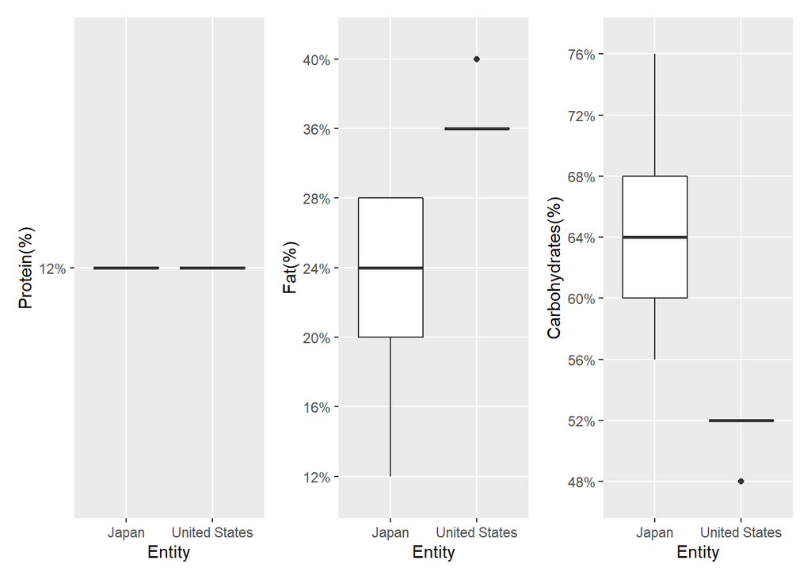

Distribution of Protein,Fat,Carbohydrates

Figure@ref(fig:Distribution-of-Protein-Fat-Carbohydrates-boxplot) shows that in terms of diet, the difference in the proportion of protein calories consumed in Japan and the United States is not large, and the values are both around 12%. The proportion of fat and carbohydrates in the calorie intake in Japan and the United States is quite different. The proportion of fat in the Japanese diet is mostly between 20% and 28%, while the proportion of fat in the American diet is between 36% and 38%. between. Carbohydrates, on the other hand, are mostly between 60% and 68% carbohydrates in the Japanese diet, compared to 50% to 52% in the American diet. We learned from the survey that this is due to the differences in food culture, geographical environment, historical and cultural differences between the two regions. The geographical location of Japan is close to the sea, and the Japanese diet is relatively light. Therefore, special attention is paid to the intake of fats and oils in the daily calorie intake. The Japanese diet has a high proportion of ramen and rice, so the proportion of carbohydrates is also high. The American diet has a high fat content, and Americans like to use cooking methods such as frying and roasting, which has also led to a large increase in the proportion of fat.

# Question2

2. What is the difference between the time trends of TotalCalories and Calories of Protein, Fat, Carbohydrates in the two countries?

Table analysis of both countries

```r
summary_US <- US_Data %>%
  dplyr::select(total_Cal,Protein_Cal,Fat_Cal,Carbohydrates_Cal) %>%
  summary() %>%
  knitr::kable(caption = "Calories Intake of United States") %>%
         kable_styling(latex_options = "hold_position")

summary_US
```

Calories Intake of United States

[output not shown]

```r
summary_Japan <- Japan_Data %>%
  dplyr::select(total_Cal,Protein_Cal,Fat_Cal,Carbohydrates_Cal) %>%
  summary() %>%
  knitr::kable(caption = "Calories Intake of Japan") %>%
         kable_styling(latex_options = "hold_position")

summary_Japan
```

Calories Intake of Japan

|  | total_Cal | Protein_Cal | Fat_Cal | Carbohydrates_Cal |
| --- | --- | --- | --- | --- |
|  | Min. :2525 | Min. :296.8 | Min. :310.4 | Min. :1547 |
|  | 1st Qu.:2730 | 1st Qu.:339.9 | 1st Qu.:558.4 | 1st Qu.:1727 |
|  | Median :2810 | Median :359.5 | Median :694.9 | Median :1800 |
|  | Mean :2800 | Mean :357.2 | Mean :652.0 | Mean :1790 |
|  | 3rd Qu.:2895 | 3rd Qu.:380.6 | 3rd Qu.:791.8 | 3rd Qu.:1860 |
|  | Max. :2969 | Max. :392.9 | Max. :815.5 | Max. :1962 |

It can be seen from Table@ref(tab:Calories-Intake-of-United-States), that the mean Calories of United States is 3354 kcal while Table@ref(tab:Calories-Intake-of-Japan) shows Japan’s mean Calories is 2800. The overall calorie intake of the American diet is significantly higher than that of the Japanese diet, which may also explain why there are many obese people in the United States. In addition, we can observe that the average carbohydrate intake of the Japanese and American diets is almost the same in terms of the average calorie intake of the three nutrients, but the fat intake of the American diet is significantly higher than that of the Japanese diet.

[figure not shown]

```r
plot_Calories_Intake <- mydata%>%
  ggplot(section2_chile_canada, mapping =  aes(
    x = Year,
    y = Protein_Cal,
    color = Entity)) +
  geom_line() +
  theme_bw() +
  xlab("Year") +
  ylab("Total Calories Intake") +
  ggtitle("Calories Intake of over the years")
plot_Calories_Intake
```

As above we found that fat is the biggest differentiating factor between the two countries. Therefore, we further investigated the trend of fat intake over time.

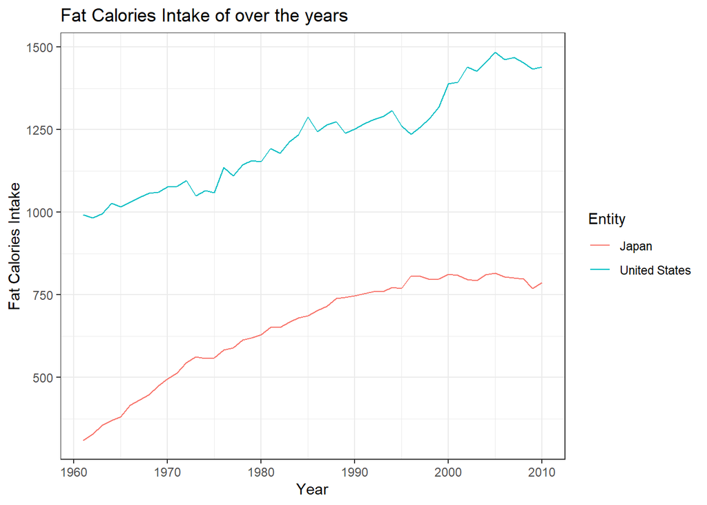

Fat Calories Intake of over the years

```r
plot_Fat_Calories_Intake <- mydata%>%
  ggplot(section2_chile_canada, mapping =  aes(
    x = Year,
    y = Fat_Cal,
    color = Entity)) +
  geom_line() +
  theme_bw() +
  xlab("Year") +
  ylab("Fat Calories Intake") +
  ggtitle("Fat Calories Intake of over the years")
plot_Fat_Calories_Intake
```

Figure@ref(fig:Fat-Calories-Intake-of-over-the-years) shows the trend of fat calories intake in the United States and Japan over time.

# Conclusion

All in all, with the development of society and the progress of economy, how to maintain a healthy eating habit has become an increasingly important issue @1992Calories. In addition to paying attention to the total calorie intake of the diet, people also need to pay attention to the energy supply ratio of the three major nutrients, protein, fat and carbohydrates. Reasonable arrangement of the proportion of nutrients can help us maintain a healthier body and prolong our energy consumption. longevity and reduce the incidence of disease @1990Changing.

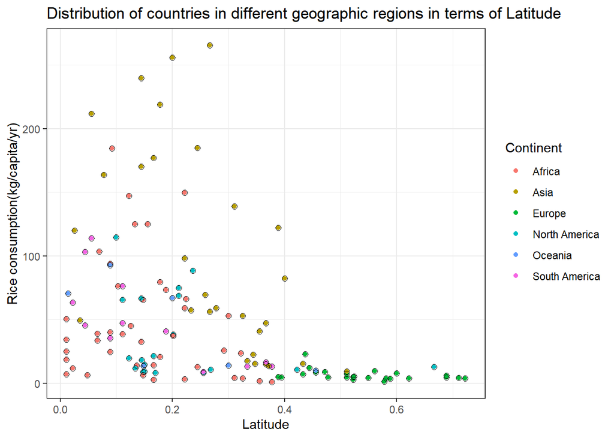

```r
ggplot(data = data_tidy,
aes(x = Latitude,
    y = `Rice consumption(kg/capita/yr)`)) +
 geom_point(aes(colour = Continent)) +
 geom_point(data = data_tidy,
 size = 2,
 shape = 1)+
  theme_bw()+
  ggtitle("Distribution of countries in different geographic regions in terms of Latitude")
```